# Zotero Report

## 5 Things Every School District and Educator Should Know About ChatGPT - TalkingPoints

- | Item Type | Web Page |
  | --- | --- |
  | Abstract | In schools and conferences across the country, everyone seems to be talking about AI (Artificial Intelligence) and ChatGPT. Teachers are using ChatGPT to create lesson plans. Students are using ChatGP… |
  | Date | 2023-04-20T17:15:13+00:00 |
  | Language | en-US |
  | URL | https://talkingpts.org/blog/5-things-every-school-district-and-educator-should-know-about-chatgpt/10766/ |
  | Accessed | 4/23/2023, 6:36:40 PM |
  | Date Added | 4/23/2023, 6:36:40 PM |
  | Modified | 4/23/2023, 6:36:40 PM |

### Attachments

  - Snapshot

## A New Approach To Mitigating AI’s Negative Impact

- | Item Type | Web Page |
  | --- | --- |
  | Abstract | Stanford launches an Ethics and Society Review Board that asks researchers to take an early look at the impact of their work. |
  | Language | en |
  | URL | https://hai.stanford.edu/news/new-approach-mitigating-ais-negative-impact |
  | Accessed | 4/26/2023, 9:08:11 AM |
  | Website Title | Stanford HAI |
  | Date Added | 4/26/2023, 9:08:16 AM |
  | Modified | 4/26/2023, 9:08:16 AM |

### Attachments

  - Snapshot

## A.I. poses existential risk of people being 'harmed or killed,' ex-Google CEO Eric Schmidt says

- | Item Type | Web Page |
  | --- | --- |
  | Author | Arjun Kharpal |
  | Abstract | Artificial intelligence has been thrust into the center of conversations among policymakers grappling with what the tech should look like in the future. |
  | Date | 2023-05-24 |
  | URL | https://www.cnbc.com/2023/05/24/ai-poses-existential-risk-former-google-ceo-eric-schmidt-says.html |
  | Accessed | 5/25/2023, 5:42:18 AM |
  | Date Added | 5/25/2023, 5:42:18 AM |
  | Modified | 5/25/2023, 5:42:18 AM |

## Assessment redesign for generative AI: A taxonomy of options and their viability

- | Item Type | Web Page |
  | --- | --- |
  | Abstract | with Sarah Howard and Jaclyn Broadbent Since the seemingly sudden emergence of ChatGPT at the end of 2022, there has been significant debate surrounding the impact of text-based generative AI in educa… |
  | Short Title | Assessment redesign for generative AI |
  | URL | https://www.linkedin.com/pulse/assessment-redesign-generative-ai-taxonomy-options-viability-lodge |
  | Accessed | 5/2/2023, 2:35:11 AM |
  | Date Added | 5/2/2023, 2:35:11 AM |
  | Modified | 5/2/2023, 2:35:11 AM |

## Can Large Language Models Provide Feedback to Students? A Case Study on ChatGPT

- | Item Type | Preprint |
  | --- | --- |
  | Author | Wei Dai |
  | Author | Jionghao Lin |
  | Author | Flora Jin |
  | Author | Tongguang Li |
  | Author | Yi-Shan Tsai |
  | Author | Dragan Gasevic |
  | Author | Guanliang Chen |
  | Abstract | Educational feedback has been widely acknowledged as an effective approach to improving student learning. However, scaling effective practices can be laborious and costly, which motivated researchers … |
  | Date | 2023-04-13T06:49:18.913Z |
  | Language | en-us |
  | Short Title | Can Large Language Models Provide Feedback to Students? |
  | Library Catalog | OSF Preprints |
  | URL | https://edarxiv.org/hcgzj/ |
  | Accessed | 5/23/2023, 6:41:27 AM |
  | DOI | 10.35542/osf.io/hcgzj |
  | Repository | EdArXiv |
  | Date Added | 5/23/2023, 6:41:27 AM |
  | Modified | 5/23/2023, 6:41:41 AM |

### Tags:

  - and Research
  - Automated Feedback
  - Education
  - Educational Assessment
  - Educational Methods
  - Evaluation
  - Feedback Effectiveness
  - Feedback Generation
  - Higher Education
  - Large Language Model

### Attachments

  - Full Text PDF

## ChatGPT — Show me the Data Sources

- | Item Type | Blog Post |
  | --- | --- |
  | Author | Dennis Layton |
  | Abstract | What are the data sources for ChatGPT ? We are all struggling with the heuristic nature of AI, but knowing where the data comes from might… |
  | Date | 2023-01-30T21:29:03.644Z |
  | Language | en |
  | URL | https://medium.com/@dlaytonj2/chatgpt-show-me-the-data-sources-11e9433d57e8 |
  | Accessed | 5/1/2023, 12:57:54 PM |
  | Blog Title | Medium |
  | Date Added | 5/1/2023, 12:57:54 PM |
  | Modified | 5/1/2023, 12:57:54 PM |

## Conversational agents in language learning

- | Item Type | Journal Article |
  | --- | --- |
  | Author | Feiwen Xiao |
  | Author | Priscilla Zhao |
  | Author | Hanyue Sha |
  | Author | Dandan Yang |
  | Author | Mark Warschauer |
  | Abstract | Due to advances in technology, conversational agents are emerging as intelligent spoken dialogue systems that simulate natural conversation with human beings. A growing body of literature has investig… |
  | Date | 2023-03-28 |
  | Language | en |
  | Library Catalog | www.degruyter.com |
  | URL | https://www.degruyter.com/document/doi/10.1515/jccall-2022-0032/html |
  | Accessed | 3/28/2023, 6:54:51 PM |
  | Extra | Publisher: De Gruyter |
  | Publication | Journal of China Computer-Assisted Language Learning |
  | DOI | 10.1515/jccall-2022-0032 |
  | ISSN | 2748-3479 |
  | Date Added | 4/20/2023, 6:49:12 AM |
  | Modified | 4/20/2023, 6:49:12 AM |

### Tags:

  - technology
  - CALL
  - conversational agents
  - language learning
  - natural language processing (NLP)

### Attachments

  - Full Text PDF

## Educational Research and AI-Generated Writing: Confronting the Coming Tsunami

- | Item Type | Preprint |
  | --- | --- |
  | Author | Tamara Tate |
  | Author | Shayan Doroudi |
  | Author | Daniel Ritchie |
  | Author | Ying Xu |
  | Author | Mark Warschauer Uci |
  | Abstract | The public release and surprising capacity of ChatGPT has brought AI-enabled text generation into the forefront for educators and academics. ChatGPT and similar text generation tools raise numerous qu… |
  | Date | 2023-01-10T17:44:26.337Z |
  | Language | en-us |
  | Short Title | Educational Research and AI-Generated Writing |
  | Library Catalog | OSF Preprints |
  | URL | https://edarxiv.org/4mec3/ |
  | Accessed | 3/17/2023, 12:51:23 PM |
  | DOI | 10.35542/osf.io/4mec3 |
  | Repository | EdArXiv |
  | Date Added | 4/20/2023, 6:52:35 AM |
  | Modified | 4/20/2023, 6:52:35 AM |

### Tags:

  - Education
  - technology
  - education
  - Artificial Intelligence
  - ml
  - Language and Literacy Education
  - literacy

### Attachments

  - Full Text PDF

## ESR: Ethics and Society Review of Artificial Intelligence Research

- | Item Type | Preprint |
  | --- | --- |
  | Author | Michael S. Bernstein |
  | Author | Margaret Levi |
  | Author | David Magnus |
  | Author | Betsy Rajala |
  | Author | Debra Satz |
  | Author | Charla Waeiss |
  | Abstract | Artificial intelligence (AI) research is routinely criticized for its real and potential impacts on society, and we lack adequate institutional responses to this criticism and to the responsibility th… |
  | Date | 2021-07-09 |
  | Short Title | ESR |
  | Library Catalog | arXiv.org |
  | URL | http://arxiv.org/abs/2106.11521 |
  | Accessed | 4/26/2023, 4:48:14 PM |
  | Extra | arXiv:2106.11521 [cs] |
  | DOI | 10.48550/arXiv.2106.11521 |
  | Repository | arXiv |
  | Archive ID | arXiv:2106.11521 |
  | Date Added | 4/26/2023, 4:48:14 PM |
  | Modified | 4/26/2023, 4:48:27 PM |

### Tags:

  - Computer Science - Computers and Society
  - ethics
  - K.4

### Notes:

  - Comment: Revision: credit to the Microsoft Research Ethics Review Program

### Attachments

  - arXiv Fulltext PDF
  - arXiv.org Snapshot

## Exploring User Perspectives on ChatGPT: Applications, Perceptions, and Implications for AI-Integrated Education

- | Item Type | Preprint |
  | --- | --- |
  | Author | Reza Hadi Mogavi |
  | Author | Chao Deng |
  | Author | Justin Juho Kim |
  | Author | Pengyuan Zhou |
  | Author | Young D. Kwon |
  | Author | Ahmed Hosny Saleh Metwally |
  | Author | Ahmed Tlili |
  | Author | Simone Bassanelli |
  | Author | Antonio Bucchiarone |
  | Author | Sujit Gujar |
  | Author | Lennart E. Nacke |
  | Author | Pan Hui |
  | Abstract | Understanding user perspectives on Artificial Intelligence (AI) in education is essential for creating pedagogically effective and ethically responsible AI-integrated learning environments. In this pa… |
  | Date | 2023-05-22 |
  | Short Title | Exploring User Perspectives on ChatGPT |
  | Library Catalog | arXiv.org |
  | URL | http://arxiv.org/abs/2305.13114 |
  | Accessed | 5/25/2023, 5:54:06 AM |
  | Extra | arXiv:2305.13114 [cs] |
  | DOI | 10.48550/arXiv.2305.13114 |
  | Archive ID | arXiv:2305.13114 |
  | Date Added | 5/25/2023, 5:54:06 AM |
  | Modified | 5/25/2023, 5:54:06 AM |

### Tags:

  - Computer Science - Computers and Society
  - Computer Science - Human-Computer Interaction

### Attachments

  - Mogavi et al. - 2023 - Exploring User Perspectives on ChatGPT Applications, Perceptions, and Implications for AI-Integrated Education.pdf

## FATE (Fairness and Transparency) Hits the Mainstream: UK's 5 Principles for AI Regulation

- | Item Type | Web Page |
  | --- | --- |
  | Author | Robert Harris |
  | Abstract | The UK released a whitepaper detailing a pro-innovation approach to AI regulation. Here are the potential impacts for banks |
  | Date | 2023-03-29T18:29:37+00:00 |
  | Language | en-US |
  | Short Title | FATE (Fairness and Transparency) Hits the Mainstream |
  | URL | https://feedzai.com/blog/fate-fairness-and-transparency-hits-the-mainstream-uks-5-principles-for-ai-regulation/ |
  | Accessed | 5/24/2023, 3:08:48 PM |
  | Website Title | Feedzai |
  | Date Added | 5/24/2023, 3:08:48 PM |
  | Modified | 5/24/2023, 3:08:48 PM |

### Attachments

  - Snapshot

## GPT-4 Technical Report

- | Item Type | Preprint |
  | --- | --- |
  | Author | OpenAI |
  | Abstract | We report the development of GPT-4, a large-scale, multimodal model which can accept image and text inputs and produce text outputs. While less capable than humans in many real-world scenarios, GPT-4 … |
  | Date | 2023-03-27 |
  | Library Catalog | arXiv.org |
  | URL | http://arxiv.org/abs/2303.08774 |
  | Accessed | 5/1/2023, 3:53:55 PM |
  | Extra | arXiv:2303.08774 [cs] |
  | DOI | 10.48550/arXiv.2303.08774 |
  | Repository | arXiv |
  | Archive ID | arXiv:2303.08774 |
  | Date Added | 5/1/2023, 3:53:55 PM |
  | Modified | 5/1/2023, 3:53:55 PM |

### Tags:

  - Computer Science - Artificial Intelligence
  - Computer Science - Computation and Language

### Notes:

  - Comment: 100 pages

### Attachments

  - arXiv Fulltext PDF
  - arXiv.org Snapshot

## GPTs are GPTs: An Early Look at the Labor Market Impact Potential of Large Language Models

- | Item Type | Preprint |
  | --- | --- |
  | Author | Tyna Eloundou |
  | Author | Sam Manning |
  | Author | Pamela Mishkin |
  | Author | Daniel Rock |
  | Abstract | We investigate the potential implications of Generative Pre-trained Transformer (GPT) models and related technologies on the U.S. labor market. Using a new rubric, we assess occupations based on their… |
  | Date | 2023-03-21 |
  | Short Title | GPTs are GPTs |
  | Library Catalog | arXiv.org |
  | URL | http://arxiv.org/abs/2303.10130 |
  | Accessed | 3/25/2023, 8:43:54 AM |
  | Extra | arXiv:2303.10130 [cs, econ, q-fin] |
  | Repository | arXiv |
  | Archive ID | arXiv:2303.10130 |
  | Date Added | 4/20/2023, 6:49:12 AM |
  | Modified | 4/20/2023, 6:49:12 AM |

### Tags:

  - Computer Science - Computers and Society
  - Computer Science - Artificial Intelligence
  - Economics - General Economics

### Notes:

  - Proposed impact on wages from GPT - and cute name.

    Estimate: 19% of workers, 50% of tasks impacted - at ALL WAGE LEVELS. Not just de-skilled labor.

    Call it a transformative technology - social, political, policy implications. Investigate using ChatGPT 4.

[figure not shown]

    “Our findings” (Eloundou et al., 2023, p. 3). - WTF is the method for evaluating the likelihood of working/having them successfully replaced? No clue.

    “However, we argue that it is essential to view GPTs as versatile building blocks for creating additional tools.” (Eloundou et al., 2023, p. 4)
    - Unclear what the methods are; econ article structure puts findings first, then goes into lit review and methods, unlike education articles.

    “In other words, while it’s true that on its own GPT-4 does not "know what time it is," it’s easy enough to give it a watch.” (Eloundou et al., 2023, p. 4)

    Very interesting quote and positioning of ChatGPT as a tool that is NOT stand-alone, but instead is embedded within other applications.

    “we define exposure as a measure of whether access to a GPT or GPT-powered system would reduce the time required for a human to perform a specific DWA or complete a task by at least 50 percent” (Eloundou et al., 2023, p. 7)

### Attachments

  - arXiv Fulltext PDF
  - arXiv.org Snapshot

## How ChatGPT Works: The Models Behind The Bot

- | Item Type | Web Page |
  | --- | --- |
  | Author | Molly Ruby |
  | Abstract | A brief introduction to the intuition and methodology behind the chat bot you can’t stop hearing about. |
  | Date | 2023-02-16T20:19:20.213Z |
  | Language | en |
  | Short Title | How ChatGPT Works |
  | URL | https://towardsdatascience.com/how-chatgpt-works-the-models-behind-the-bot-1ce5fca96286 |
  | Accessed | 5/1/2023, 12:56:25 PM |
  | Website Title | Medium |
  | Date Added | 5/1/2023, 12:56:25 PM |
  | Modified | 5/1/2023, 12:56:25 PM |

## How Useful are Educational Questions Generated by Large Language Models?

- | Item Type | Preprint |
  | --- | --- |
  | Author | Sabina Elkins |
  | Author | Ekaterina Kochmar |
  | Author | Jackie C. K. Cheung |
  | Author | Iulian Serban |
  | Abstract | Controllable text generation (CTG) by large language models has a huge potential to transform education for teachers and students alike. Specifically, high quality and diverse question generation can … |
  | Date | 2023-04-13 |
  | Library Catalog | arXiv.org |
  | URL | http://arxiv.org/abs/2304.06638 |
  | Accessed | 4/21/2023, 4:48:01 PM |
  | Extra | arXiv:2304.06638 [cs] |
  | Repository | arXiv |
  | Archive ID | arXiv:2304.06638 |
  | Date Added | 4/21/2023, 4:48:01 PM |
  | Modified | 4/21/2023, 4:48:01 PM |

### Tags:

  - Computer Science - Computers and Society
  - Computer Science - Machine Learning
  - Computer Science - Artificial Intelligence
  - Computer Science - Computation and Language

### Notes:

  - Comment: Accepted to AIED Late Breaking Results 2023 - to be published in their proceedings

### Attachments

  - arXiv Fulltext PDF
  - arXiv.org Snapshot

## How Well Do Large Language Models Support Clinician Information Needs?

- | Item Type | Web Page |
  | --- | --- |
  | Abstract | Stanford experts examine the safety and accuracy of GPT-4 in serving curbside consultation needs of doctors. |
  | Language | en |
  | URL | https://hai.stanford.edu/news/how-well-do-large-language-models-support-clinician-information-needs |
  | Accessed | 5/19/2023, 11:55:04 AM |
  | Website Title | Stanford HAI |
  | Date Added | 5/19/2023, 11:55:07 AM |
  | Modified | 5/19/2023, 11:55:07 AM |

### Attachments

  - Snapshot

## Large, creative AI models will transform lives and labour markets

- | Item Type | Magazine Article |
  | --- | --- |
  | Library Catalog | The Economist |
  | URL | https://www.economist.com/interactive/science-and-technology/2023/04/22/large-creative-ai-models-will-transform-how-we-live-and-work |
  | Accessed | 5/21/2023, 7:13:16 AM |
  | Publication | The Economist |
  | ISSN | 0013-0613 |
  | Date Added | 5/21/2023, 7:13:16 AM |
  | Modified | 5/21/2023, 7:13:16 AM |

### Attachments

  - The Economist Snapshot

## Learning gain differences between ChatGPT and human tutor generated algebra hints

- | Item Type | Preprint |
  | --- | --- |
  | Author | Zachary A. Pardos |
  | Author | Shreya Bhandari |
  | Abstract | Large Language Models (LLMs), such as ChatGPT, are quickly advancing AI to the frontiers of practical consumer use and leading industries to re-evaluate how they allocate resources for content product… |
  | Date | 2023-02-14 |
  | Library Catalog | arXiv.org |
  | URL | http://arxiv.org/abs/2302.06871 |
  | Accessed | 5/23/2023, 6:35:10 AM |
  | Extra | arXiv:2302.06871 [cs] |
  | DOI | 10.48550/arXiv.2302.06871 |
  | Repository | arXiv |
  | Archive ID | arXiv:2302.06871 |
  | Date Added | 5/23/2023, 6:35:10 AM |
  | Modified | 5/23/2023, 6:41:54 AM |

### Tags:

  - Computer Science - Computation and Language
  - Computer Science - Computers and Society
  - Computer Science - Human-Computer Interaction

### Attachments

  - arXiv Fulltext PDF
  - arXiv.org Snapshot

## MathGPT is incoming; how it fits into undergraduate math education - The Arizona State Press

- | Item Type | Web Page |
  | --- | --- |
  | Abstract | Arizona State University's independent student-run news organization covering Tempe, Phoenix, Mesa and Glendale. |
  | URL | https://www.statepress.com/article/2023/04/mathgpt-math-education |
  | Accessed | 4/30/2023, 9:06:06 AM |
  | Date Added | 4/30/2023, 9:06:06 AM |
  | Modified | 4/30/2023, 9:06:06 AM |

## Meet RedPajama: An AI Project to Create Fully Open-Source Large Language Models Beginning with the Release of a 1.2 Trillion Token Dataset

- | Item Type | Blog Post |
  | --- | --- |
  | Author | Niharika Singh |
  | Abstract | The most advanced foundation models for AI are only partially open-source and are only available through commercial APIs. This restricts their use and limits research and customization. However, a pro… |
  | Date | 2023-04-21T05:00:48-07:00 |
  | Language | en-US |
  | Short Title | Meet RedPajama |
  | URL | https://www.marktechpost.com/2023/04/21/meet-redpajama-an-ai-project-to-create-fully-open-source-large-language-models-beginning-with-the-release-of-a-1-2-trillion-token-dataset/ |
  | Accessed | 4/26/2023, 9:16:29 AM |
  | Blog Title | MarkTechPost |
  | Date Added | 4/26/2023, 9:16:29 AM |
  | Modified | 4/26/2023, 9:16:29 AM |

### Attachments

  - Snapshot

## MxML (Exploring the paradigmatic relationship between measurement and machine learning in the history, current time, and future): Current state-of-the-field

- | Item Type | Conference Paper |
  | --- | --- |
  | Author | Yi Zheng |
  | Author | Steven Nydick |
  | Author | Sijia Huang |
  | Author | Susu Zhang |
  | Abstract | The recent surge of machine learning (ML) has impacted many disciplines, including educational and psychological measurement (hereafter shortened as measurement, “M”). The measurement literature has s… |
  | Date | April 12, 2023 |
  | Place | Chicago, IL |
  | Conference Name | NCME |
  | DOI | https://edarxiv.org/n9reh |
  | Date Added | 4/20/2023, 6:53:38 AM |
  | Modified | 4/22/2023, 1:02:42 PM |

### Attachments

  - Zheng et al. - 2023 - MxML (Exploring the paradigmatic relationship betw.pdf

## Noy_Zhang_1.pdf

- | Item Type | Attachment |
  | --- | --- |
  | URL | https://economics.mit.edu/sites/default/files/inline-files/Noy_Zhang_1.pdf |
  | Accessed | 5/16/2023, 6:06:27 AM |
  | Date Added | 5/16/2023, 6:06:27 AM |
  | Modified | 5/16/2023, 6:06:27 AM |

## Office Overachievers Won't Be Happy About ChatGPT, Study Finds

- | Item Type | Web Page |
  | --- | --- |
  | Abstract | Customer support agents given access to a generative AI chatbot were 14% more productive, but those gains were much higher for lower-performing workers. |
  | Date | 2023-04-24T17:13:52.933Z |
  | Language | en |
  | URL | https://gizmodo.com/ai-chatgpt-customer-service-overachievers-productive-1850368672 |
  | Accessed | 4/26/2023, 4:42:04 PM |
  | Website Title | Gizmodo |
  | Date Added | 4/26/2023, 4:42:04 PM |
  | Modified | 4/26/2023, 4:42:04 PM |

### Attachments

  - Snapshot

## Outsider Oversight: Designing a Third Party Audit Ecosystem for AI Governance

- | Item Type | Preprint |
  | --- | --- |
  | Author | Inioluwa Deborah Raji |
  | Author | Peggy Xu |
  | Author | Colleen Honigsberg |
  | Author | Daniel E. Ho |
  | Abstract | Much attention has focused on algorithmic audits and impact assessments to hold developers and users of algorithmic systems accountable. But existing algorithmic accountability policy approaches have … |
  | Date | 2022-06-09 |
  | Short Title | Outsider Oversight |
  | Library Catalog | arXiv.org |
  | URL | http://arxiv.org/abs/2206.04737 |
  | Accessed | 4/26/2023, 4:42:41 PM |
  | Extra | arXiv:2206.04737 [cs] |
  | DOI | 10.48550/arXiv.2206.04737 |
  | Repository | arXiv |
  | Archive ID | arXiv:2206.04737 |
  | Date Added | 4/26/2023, 4:42:41 PM |
  | Modified | 4/26/2023, 4:42:41 PM |

### Tags:

  - Computer Science - Computers and Society

### Notes:

  - Comment: Presented at 5th Annual ACM/AAAI AI Ethics and Society (AIES) conference

### Attachments

  - arXiv Fulltext PDF
  - arXiv.org Snapshot

## Reflexion: Language Agents with Verbal Reinforcement Learning

- | Item Type | Preprint |
  | --- | --- |
  | Author | Noah Shinn |
  | Author | Federico Cassano |
  | Author | Beck Labash |
  | Author | Ashwin Gopinath |
  | Author | Karthik Narasimhan |
  | Author | Shunyu Yao |
  | Abstract | Large language models (LLMs) have been increasingly used to interact with external environments (e.g., games, compilers, APIs) as goal-driven agents. However, it remains challenging for these language… |
  | Date | 2023-05-21 |
  | Short Title | Reflexion |
  | Library Catalog | arXiv.org |
  | URL | http://arxiv.org/abs/2303.11366 |
  | Accessed | 5/25/2023, 5:59:15 AM |
  | Extra | arXiv:2303.11366 [cs] |
  | DOI | 10.48550/arXiv.2303.11366 |
  | Repository | arXiv |
  | Archive ID | arXiv:2303.11366 |
  | Date Added | 5/25/2023, 5:59:15 AM |
  | Modified | 5/25/2023, 5:59:31 AM |

### Tags:

  - Computer Science - Artificial Intelligence
  - Computer Science - Computation and Language
  - Computer Science - Machine Learning

### Notes:

  - Comment: v2 contains additional experiments

### Attachments

  - arXiv Fulltext PDF
  - arXiv.org Snapshot

## Responsible Use of Generative AI | Deloitte US

- | Item Type | Web Page |
  | --- | --- |
  | URL | https://www2.deloitte.com/us/en/pages/consulting/articles/responsible-use-of-generative-ai.html?id=us:2sm:3li:4dcom_share:5awa:6dcom:consulting |
  | Accessed | 4/28/2023, 4:15:32 AM |
  | Date Added | 4/28/2023, 4:15:32 AM |
  | Modified | 4/28/2023, 4:15:32 AM |

## Sabiá: Portuguese Large Language Models

- | Item Type | Preprint |
  | --- | --- |
  | Author | Ramon Pires |
  | Author | Hugo Abonizio |
  | Author | Thales Sales Almeida |
  | Author | Rodrigo Nogueira |
  | Abstract | As the capabilities of language models continue to advance, it is conceivable that "one-size-fits-all" model will remain as the main paradigm. For instance, given the vast number of languages worldwid… |
  | Date | 2023 |
  | Short Title | Sabiá |
  | Library Catalog | DOI.org (Datacite) |
  | URL | https://arxiv.org/abs/2304.07880 |
  | Accessed | 4/20/2023, 6:28:30 AM |
  | Rights | Creative Commons Attribution 4.0 International |
  | DOI | 10.48550/ARXIV.2304.07880 |
  | Date Added | 4/20/2023, 6:28:30 AM |
  | Modified | 5/25/2023, 9:30:34 AM |

### Tags:

  - Artificial Intelligence (cs.AI)
  - Computation and Language (cs.CL)
  - fine-tune
  - FOS: Computer and information sciences
  - LLM

### Notes:

  - CF: IMO, Language also = symbolic math, specialized jargon of disciplines (Legalese etc.), etc.

## Study Finds ChatGPT Outperforms Physicians in High-Quality, Empathetic Answers to Patient Questions

- | Item Type | Web Page |
  | --- | --- |
  | Abstract | A new study published in JAMA Internal Medicine compared written responses from physicians with those from ChatGPT to real-world health questions. A panel of licensed healthcare professionals preferre… |
  | URL | https://today.ucsd.edu/story/study-finds-chatgpt-outperforms-physicians-in-high-quality-empathetic-answers-to-patient-questions |
  | Accessed | 5/1/2023, 6:13:56 AM |
  | Date Added | 5/1/2023, 6:13:56 AM |
  | Modified | 5/1/2023, 6:13:56 AM |

## Teacher Coaching - ACL preprint

- | Item Type | Document |
  | --- | --- |
  | Author | demzsky |
  | Date Added | 5/23/2023, 6:30:42 AM |
  | Modified | 5/23/2023, 6:31:15 AM |

### Notes:

  - Use 3.5, no prompting, no training. Shows that “zero shot” learning to generalized doesn’t work well.

    “Our results show that 533 ChatGPT does generate a non-trivial amount of 534 misleading responses as measured by our faithful- 535 ness dimension (15-30% of the time). This ob- 536 servation is documented in the LLM literature as 537 model hallucination (Ji et al., 2023).” (demzsky, p. 7)

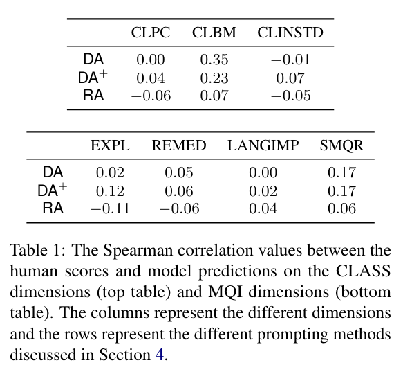

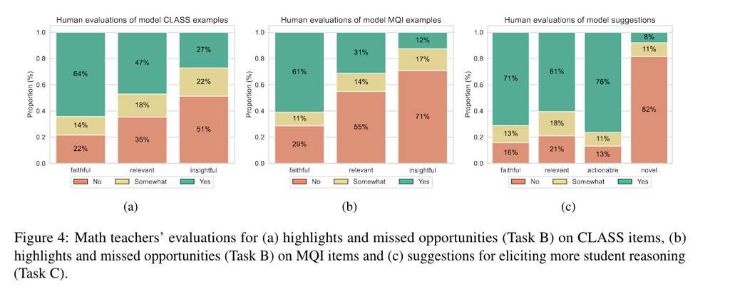

    Large task - try to score transcripts, identify/highligyt, and make actional recommendations.

    Extremely low accuracy and utility of results -

    have expert math teachers

    zero shot performance?

    “Our work 025 highlights the challenges of producing insight026 ful, novel and truthful feedback for teachers 027 while paving the way for future research to ad028 dress these obstacles and improve the capacity 029 of generative AI to coach teachers.” (demzsky, p. 1)

    Get at high-level feedback from coaching as a harder problem than low-level summary stats.

    annotation - standardized

    “Classroom Assessment Scoring System 101 (CLASS) (Pianta et al., 2008) and Mathematical 102 Quality Instruction (MQI) (Hill et al., 2008) in103 struments.” (demzsky, p. 2)

    use prior scoring first as baseline, then recruit teachers to score usefulness of responses. “We evalu110 ate ChatGPT by comparing the model’s numerical 111 predictions to raters’ scores in the NCTE data (Task 112 A). We also recruit math teachers to rate the Chat113 GPT’s responses along multiple helpfulness criteria 114 (Tasks B & C).” (demzsky, p. 2)

    “On predicting scores, ChatGPT has low cor119 relation with human ratings across all observation 120 items even with added rubric information and rea121 soning” (demzsky, p. 2)

    “A 163 similar tool, M-Powering Teachers, provides feed- 164 back to teachers on their uptake of student ideas 165 and demonstrates effectiveness in the 1-on-1 learn- 166 ing setting (Demszky and Liu, 2023).” (demzsky, p. 2)

    “1. Relevance: Is the model’s response relevant to 405 the CLASS or MQI item of interest? 406 2. Faithfulness: Does the model’s response have an 407 accurate interpretation of the events that occur 408 in the classroom transcript? 409 3. Insightfulness: Does the model’s response reveal 410 insights beyond a literal restatement of what hap- 411 pens in the transcript?” (demzsky, p. 5)

### Attachments

  - Wang_Demszky_ChatGPT_Teacher_Coach_2023.pdf

    This is a pre-print; please do not share or cite without permission.

## The Stanford MOOCPosts Data Set

- | Item Type | Conference Paper |
  | --- | --- |
  | Author | Akshay Agrawal |
  | Author | Andreas Paepcke |
  | URL | https://datastage.stanford.edu/StanfordMoocPosts/#appendix1 |
  | Accessed | 4/25/2023, 5:00:00 PM |
  | Publisher | Stanford |
  | Date Added | 4/26/2023, 8:33:15 AM |
  | Modified | 4/26/2023, 8:34:50 AM |

## The Writing Synth Hypothesis

- | Item Type | Blog Post |
  | --- | --- |
  | Author | sbs on March 24th |
  | Author | 2023 |
  | URL | https://simon.buckinghamshum.net/2023/03/the-writing-synth-hypothesis/ |
  | Accessed | 5/5/2023, 6:49:41 AM |
  | Date Added | 5/5/2023, 6:49:41 AM |
  | Modified | 5/5/2023, 6:49:41 AM |

## Towards Generalizable Detection of Urgency of Discussion Forum Posts

- | Item Type | Conference Paper |
  | --- | --- |
  | Author | Valdemar Švábenský |
  | Author | Ryan S. Baker |
  | Author | Andrés Zambrano |
  | Author | Yishan Zou |
  | Author | Stefan Slater |
  | Date | 2023 |
  | URL | https://github.com/pcla-code/forum-posts-urgency |
  | Series | EDM 2023 |
  | Proceedings Title | Proceedings of the 16th International Conference on Educational Data Mining |
  | Date Added | 4/26/2023, 8:14:53 AM |
  | Modified | 4/26/2023, 8:23:20 AM |

## Toxicity in ChatGPT: Analyzing Persona-assigned Language Models

- | Item Type | Preprint |
  | --- | --- |
  | Author | Ameet Deshpande |
  | Author | Vishvak Murahari |
  | Author | Tanmay Rajpurohit |
  | Author | Ashwin Kalyan |
  | Author | Karthik Narasimhan |
  | Abstract | Large language models (LLMs) have shown incredible capabilities and transcended the natural language processing (NLP) community, with adoption throughout many services like healthcare, therapy, educat… |
  | Date | 2023-04-11 |
  | Short Title | Toxicity in ChatGPT |
  | Library Catalog | arXiv.org |
  | URL | http://arxiv.org/abs/2304.05335 |
  | Accessed | 5/1/2023, 12:56:01 PM |
  | Extra | arXiv:2304.05335 [cs] |
  | DOI | 10.48550/arXiv.2304.05335 |
  | Repository | arXiv |
  | Archive ID | arXiv:2304.05335 |
  | Date Added | 5/1/2023, 12:56:30 PM |
  | Modified | 5/1/2023, 12:56:30 PM |

### Tags:

  - Computer Science - Machine Learning
  - Computer Science - Artificial Intelligence
  - Computer Science - Computation and Language

## Training language models to follow instructions with human feedback

- | Item Type | Preprint |
  | --- | --- |
  | Author | Long Ouyang |
  | Author | Jeff Wu |
  | Author | Xu Jiang |
  | Author | Diogo Almeida |
  | Author | Carroll L. Wainwright |
  | Author | Pamela Mishkin |
  | Author | Chong Zhang |
  | Author | Sandhini Agarwal |
  | Author | Katarina Slama |
  | Author | Alex Ray |
  | Author | John Schulman |
  | Author | Jacob Hilton |
  | Author | Fraser Kelton |
  | Author | Luke Miller |
  | Author | Maddie Simens |
  | Author | Amanda Askell |
  | Author | Peter Welinder |
  | Author | Paul Christiano |
  | Author | Jan Leike |
  | Author | Ryan Lowe |
  | Abstract | Making language models bigger does not inherently make them better at following a user's intent. For example, large language models can generate outputs that are untruthful, toxic, or simply not helpf… |
  | Date | 2022-03-04 |
  | Library Catalog | arXiv.org |
  | URL | http://arxiv.org/abs/2203.02155 |
  | Accessed | 5/1/2023, 3:51:42 PM |
  | Extra | arXiv:2203.02155 [cs] |
  | DOI | 10.48550/arXiv.2203.02155 |
  | Repository | arXiv |
  | Archive ID | arXiv:2203.02155 |
  | Date Added | 5/1/2023, 3:51:43 PM |
  | Modified | 5/1/2023, 3:51:43 PM |

### Tags:

  - Computer Science - Machine Learning
  - Computer Science - Artificial Intelligence
  - Computer Science - Computation and Language

### Attachments

  - arXiv Fulltext PDF
  - arXiv.org Snapshot

## Whose Opinions Do Language Models Reflect?

- | Item Type | Preprint |
  | --- | --- |
  | Author | Shibani Santurkar |
  | Author | Esin Durmus |
  | Author | Faisal Ladhak |
  | Author | Cinoo Lee |
  | Author | Percy Liang |
  | Author | Tatsunori Hashimoto |
  | Abstract | Language models (LMs) are increasingly being used in open-ended contexts, where the opinions reflected by LMs in response to subjective queries can have a profound impact, both on user satisfaction, a… |
  | Date | 2023-03-30 |
  | Library Catalog | arXiv.org |
  | URL | http://arxiv.org/abs/2303.17548 |
  | Accessed | 5/19/2023, 2:22:35 PM |
  | Extra | arXiv:2303.17548 [cs] |
  | DOI | 10.48550/arXiv.2303.17548 |
  | Repository | arXiv |
  | Archive ID | arXiv:2303.17548 |
  | Date Added | 5/19/2023, 2:22:42 PM |
  | Modified | 5/19/2023, 2:22:42 PM |

### Tags:

  - Computer Science - Computers and Society
  - Computer Science - Machine Learning
  - Computer Science - Artificial Intelligence
  - Computer Science - Computation and Language

## Whose Opinions Do Language Models Reflect?

- | Item Type | Preprint |
  | --- | --- |
  | Author | Shibani Santurkar |
  | Author | Esin Durmus |
  | Author | Faisal Ladhak |
  | Author | Cinoo Lee |
  | Author | Percy Liang |
  | Author | Tatsunori Hashimoto |
  | Abstract | Language models (LMs) are increasingly being used in open-ended contexts, where the opinions reflected by LMs in response to subjective queries can have a profound impact, both on user satisfaction, a… |
  | Date | 2023-03-30 |
  | Library Catalog | arXiv.org |
  | URL | http://arxiv.org/abs/2303.17548 |
  | Accessed | 5/19/2023, 2:22:35 PM |
  | Extra | arXiv:2303.17548 [cs] |
  | DOI | 10.48550/arXiv.2303.17548 |
  | Repository | arXiv |
  | Archive ID | arXiv:2303.17548 |
  | Date Added | 5/19/2023, 2:22:47 PM |
  | Modified | 5/19/2023, 2:22:47 PM |

### Tags:

  - Computer Science - Computers and Society
  - Computer Science - Machine Learning
  - Computer Science - Artificial Intelligence
  - Computer Science - Computation and Language

## Yann LeCun on LinkedIn: A survey of LLMs with a practical guide and evolutionary tree. Number of… | 21 comments

- | Item Type | Web Page |
  | --- | --- |
  | Abstract | A survey of LLMs with a practical guide and evolutionary tree. Number of LLMs from Meta &#61; 7 Number of open source LLMs from Meta &#61; 7 The architecture… \| 21 comments on LinkedIn |
  | Short Title | Yann LeCun on LinkedIn |
  | URL | https://www.linkedin.com/posts/yann-lecun_a-survey-of-llms-with-a-practical-guide-and-activity-7057527966540386304-M4_2 |
  | Accessed | 4/27/2023, 8:13:05 PM |
  | Date Added | 4/27/2023, 8:13:05 PM |
  | Modified | 4/27/2023, 8:13:05 PM |